# rOpenSci_example

Margaret Siple

3/25/2019

## Test case: using `taxize` to get taxonomic information

In this example, I use the `taxize` package to - get family information from genus names - get IUCN statuses for a list of species

### Given genus names, retrieve family names

This is a very simple (but very useful) functionality of `taxize`: you can look up the family name for a given genus. For our study, we wanted to calculate the probability of mislabeling by family instead of by genus.

```r
mislabel.by.genus <- read.csv("MislabelByGenusExample.csv")
head(mislabel.by.genus)
```

```
##    X         Genus      Prob
## 1  1 Acanthocybium 1.0000000
## 2  2     Acipenser 0.8235294
## 3 13      Arapaima 0.0000000
## 4 14      Argyrops 0.0000000
## 5 15   Argyrosomus 0.7411765
## 6 16    Argyrozona 0.1666667
```

This is what the data look like, a list of probabilities of mislabeling, by genus. Use `taxize` to get the family name for each of these genera:

```r
library(dplyr)
library(taxize)

mislabel.by.fam <- mislabel.by.genus[1:10,] %>% # subsample bc whole dataset is time-consuming
                     mutate(fam = tax_name(query = as.character(Genus),
                                           get = "family",
                                           db = "itis")$family)

head(mislabel.by.fam)
```

```
##    X         Genus      Prob            fam
## 1  1 Acanthocybium 1.0000000     Scombridae
## 2  2     Acipenser 0.8235294  Acipenseridae
## 3 13      Arapaima 0.0000000 Osteoglossidae
## 4 14      Argyrops 0.0000000       Sparidae
## 5 15   Argyrosomus 0.7411765     Sciaenidae
## 6 16    Argyrozona 0.1666667       Sparidae
```

Now we can plot the median probability of mislabeling by family:

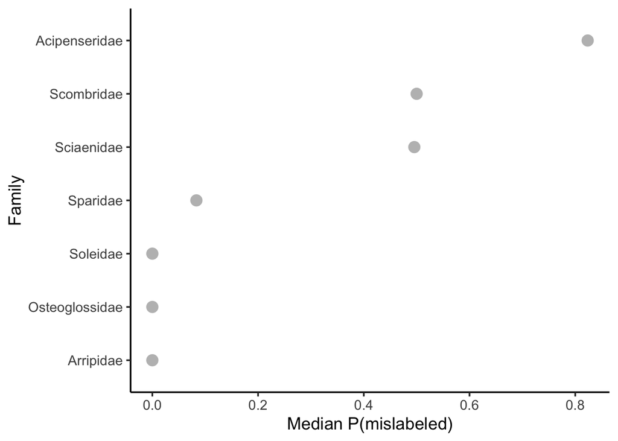

```r
library(ggplot2)

mislabel.by.fam %>%
  group_by(fam) %>%
  summarize(mProb = median(Prob)) %>%
  mutate(orderedfam = factor(fam,
                             levels = fam[order(mProb)])) %>%
  ggplot(aes(x=orderedfam,y=mProb)) +
    geom_point(size=4,colour='grey') +
    theme_classic(base_size=14) +
    labs(x="Family",y="Median P(mislabeled)") +
    coord_flip()
```

### Given a list of species names, get their IUCN status

This functionality we used in order to figure out whether, on average, the species written on the label (or menu) of seafood products was a higher conservation status (i.e., “more sustainable”) or a lower (more endangered) conservation status.

#### Getting a token for the IUCN API

In order to use `iucn_summary()` you need an API token. You can get one [here](https://apiv3.iucnredlist.org/api/v3/token). I put mine in a separate file and just use `source()` to read it in.

#### Look up an IUCN status

Once you have an API token, getting IUCN statuses is a cinch! It can take a while:

```r
source("IUCN_API.R") #file with API token

st <- Sys.time()
iucn_summary('Epinephelus diacanthus',key = IUCN_key)
```

```
## $`Epinephelus diacanthus`
## $`Epinephelus diacanthus`$status
## [1] "LC"
##
## $`Epinephelus diacanthus`$history
##   year code        category
## 1 2018   LC   Least Concern
## 2 2008   NT Near Threatened
##
## $`Epinephelus diacanthus`$distr
## [1] NA
##
## $`Epinephelus diacanthus`$trend
## [1] NA
##
##
## attr(,"class")
## [1] "iucn_summary"
```

```r
et <- Sys.time()
et - st
```

```
## Time difference of 1.252528 secs
```

#### Lookup several IUCN statuses

```r
source("IUCN_API.R")
rawdata <- read.csv("RawDataExample.csv")
head(rawdata)
```

```
##                     Sci.labels                  Sci.actuals Mislabeled
## 1               Arapaima gigas               Arapaima gigas          0
## 2 Brachyplatystoma rousseauxii Brachyplatystoma rousseauxii          0
## 3            Argyrops spinifer                  Argyrops sp          0
## 4             Cheimerius nufar             Cheimerius nufar          0
## 5           Anabas testudineus           Anabas testudineus          0
## 6               Clarias fuscus                   Clarias sp          0
##   Generally.labeled Country.of.sample                   Loc   Study Prop N
## 1                NA            Brazil Manaus and Novo Airao Study A   NA 5
## 2                NA            Brazil Manaus and Novo Airao Study A   NA 5
## 3                NA             Italy                  <NA> Study B    1 2
## 4                NA             Italy                  <NA> Study B    1 4
## 5                NA             Italy         Pisa or Prato Study B    1 1
## 6                NA             Italy         Pisa or Prato Study B    1 1
```

```r
spps <- data.frame(species = unique(c(as.character(rawdata$Sci.labels),
                                      as.character(rawdata$Sci.actuals))),
                  IUCNstatus = NA)

for(i in 1:nrow(spps)){
  s <- try(iucn_summary(as.character(spps$species[i]),key=IUCN_key))
  spps[i,'IUCNstatus'] <- iucn_status(s)
}

head(spps)
```

```
##                        species IUCNstatus
## 1               Arapaima gigas         DD
## 2 Brachyplatystoma rousseauxii         LC
## 3            Argyrops spinifer         LC
## 4             Cheimerius nufar         DD
## 5           Anabas testudineus         DD
## 6               Clarias fuscus         LC
```